# Chapter 6 homework

## Setup

```r
library(tidyverse)
library(broom)
library(modelsummary)
library(tinyplot)

tinytheme("ipsum",
         family = "Avenir Next Condensed",
         palette.qualitative = "Tableau 10",
         palette.sequential = "agSunset")
```

## Data

This homework uses a built-in dataset from base R (`state.x77`). Run the code below to create the working tibble `states`.

```r
state.x77_with_names <- as_tibble(state.x77,
                                  rownames = "state")

states <- bind_cols(state.x77_with_names,
                    region = state.division) |>
  janitor::clean_names() |>
  mutate(
    south = as.integer(
      str_detect(as.character(region), "South")
    )
  )
```

Throughout, use:

- outcome: `life_exp`
- predictor: `murder`

# Question 1: Descriptive statistics

## 1a. Descriptive statistics (psych)

Use `psych::describe()` (or something else if you want) to get descriptive statistics for `life_exp` and `murder`.

```r
pysch_states <- states |>
  select(life_exp, murder) |>
  psych::describe()

pysch_states
```

```
         vars  n  mean   sd median trimmed  mad   min  max range  skew kurtosis
life_exp    1 50 70.88 1.34  70.67   70.92 1.54 67.96 73.6  5.64 -0.15    -0.67
murder      2 50  7.38 3.69   6.85    7.30 5.19  1.40 15.1 13.70  0.13    -1.21
           se
life_exp 0.19
murder   0.52
```

## 1b. Descriptive statistics (tidyverse)

Compute (at minimum) the mean and standard deviation of `life_exp` and `murder` using `summarize()`.

```r
states |>
  summarize(mean_life_exp = mean(life_exp),
            sd_life_exp = sd(life_exp),
            mean_murder = mean(murder),
            sd_murder = sd(murder))
```

```
# A tibble: 1 × 4
  mean_life_exp sd_life_exp mean_murder sd_murder
          <dbl>       <dbl>       <dbl>     <dbl>
1          70.9        1.34        7.38      3.69
```

# Question 2a: Regression and model comparison

You will evaluate whether `murder` predicts `life_exp`.

## 2a(i). Write the model comparison and null hypothesis

Write Model C and Model A in words and equations, and state the null hypothesis.

A typical setup for testing whether a slope is needed is:

- Model C (constrained): slope fixed at 0
- Model A (augmented): slope estimated from the data

Use the notation below (fill in the missing pieces in your write-up):

Model C:
$$Y_i = 70.879 + \varepsilon_i$$

Model A:
$$Y_i = 72.974 - 0.284X_i+ \varepsilon_i$$

## 2a(ii). Fit both models

```r
model_c <- lm(life_exp ~ 1, data = states)
summary(model_c)
```

```
Call:
lm(formula = life_exp ~ 1, data = states)

Residuals:
    Min      1Q  Median      3Q     Max
-2.9186 -0.7611 -0.2036  1.0139  2.7214

Coefficients:
            Estimate Std. Error t value Pr(>|t|)
(Intercept)  70.8786     0.1898   373.4   <2e-16 ***
---
Signif. codes:  0 '***' 0.001 '**' 0.01 '*' 0.05 '.' 0.1 ' ' 1

Residual standard error: 1.342 on 49 degrees of freedom
```

```r
model_a <- lm(life_exp ~ 1 + murder, data = states)
summary(model_a)
```

```
Call:
lm(formula = life_exp ~ 1 + murder, data = states)

Residuals:
     Min       1Q   Median       3Q      Max
-1.81690 -0.48139  0.09591  0.39769  2.38691

Coefficients:
            Estimate Std. Error t value Pr(>|t|)
(Intercept) 72.97356    0.26997  270.30  < 2e-16 ***
murder      -0.28395    0.03279   -8.66 2.26e-11 ***
---
Signif. codes:  0 '***' 0.001 '**' 0.01 '*' 0.05 '.' 0.1 ' ' 1

Residual standard error: 0.8473 on 48 degrees of freedom
Multiple R-squared:  0.6097,    Adjusted R-squared:  0.6016
F-statistic: 74.99 on 1 and 48 DF,  p-value: 2.26e-11
```

```r
options(modelsummary_get = "broom")

msummary(list("MC" = model_c,
              "MA" = model_a),
         fmt = 3,
         estimate = "{estimate} ({std.error})",
         statistic = NULL,
         gof_map = c("nobs", "F", "r.squared"))
```

|  | MC | MA |
| --- | --- | --- |
| (Intercept) | 70.879 (0.190) | 72.974 (0.270) |
| murder |  | -0.284 (0.033) |
| Num.Obs. | 50 | 50 |
| F |  | 74.989 |
| R2 | 0.000 | 0.610 |

## 2a(iii). Compute SSE(C), SSE(A), PRE, and F

Compute:

- $\mathrm{SSE}_C$ and $\mathrm{SSE}_A$ from the fitted models
- $\mathrm{PRE} = (\mathrm{SSE}_C - \mathrm{SSE}_A)/\mathrm{SSE}_C$
- the model-comparison $F$ statistic

Use `deviance()` for SSE (RSS) and `df.residual()` as needed.

$$F = \frac{(\mathrm{SSE}_C - \mathrm{SSE}_A)/(P_A - P_C)}{\mathrm{SSE}_A/(n - P_A)}.$$

```r
sse_c <- deviance(model_c)
sse_a <- deviance(model_a)

pre <- (sse_c - sse_a) / sse_c
pre
```

```
[1] 0.6097201
```

```r
pa <- 2
pc <- 1
n <- 50

f <- ((sse_c - sse_a)/(pa - pc)) / (sse_a/(n - pa))
f
```

```
[1] 74.98865
```

```r
p_val <- 1 - pf(f, 1, 48)
p_val
```

```
[1] 2.26007e-11
```

```r
f_crit <- qf(1 - p_val, 49, 48)
f_crit
```

```
[1] 7.793543
```

## 2a(iv). Write the prediction equation and interpret coefficients

Write the prediction equation implied by Model A:

$$\widehat{life\_exp} = 72.97 - 0.28\, murder$$

Interpret:

## 2a(v). Conclusion

State:

- statistical conclusion (report $F$ or $t$, PRE, and $p$)
- substantive conclusion (in plain language)

Moving from model C to model A reduces error by about 61% (PRE = .610). The F statistic for the model is 74.989, which beats the critical F value of 7.794 at a p-value of 2.26007e-11. Thus, we can reject the null hypothesis that the murder rate does not predict life expectancy. This means that model A is a better fit for the data than model C.

# Question 2b: Center the predictor

Create a centered version of murder:

## 2b(i). Create `murder_c` and refit the model

```r
states <- states |>
  mutate(murder_c = murder - mean(murder))

fit_cent <- lm(life_exp ~ murder_c, data = states)

msummary(list("Centered" = fit_cent),
         fmt = 3,
         estimate = "{estimate} ({std.error})",
         statistic = NULL,
         gof_map = c("nobs", "F", "r.squared"))
```

|  | Centered |
| --- | --- |
| (Intercept) | 70.879 (0.120) |
| murder_c | -0.284 (0.033) |
| Num.Obs. | 50 |
| F | 74.989 |
| R2 | 0.610 |

## 2b(ii). Report SSE(A), SSE(C), PRE, and F again

Compute the same fit statistics (SSE, PRE, F). Compare them to the results from Question 2a.

```r
c_sse_a <- deviance(fit_cent)

pre_cent <- (sse_c - c_sse_a) / sse_c
pre_cent
```

```
[1] 0.6097201
```

```r
pa <- 2
pc <- 1
n <- 50

f_cent <- ((sse_c - c_sse_a)/(pa - pc)) / (c_sse_a/(n - pa))
f_cent
```

```
[1] 74.98865
```

The fit statistics remain the same as in question 2a.

## 2b(iii). Interpret coefficients after centering

Write the prediction equation for the centered model and interpret the intercept and slope.

In particular: what does the intercept represent *now*?

$$\widehat{life\_exp} = 70.87 - 0.28\, murder$$

## 2b(iv). Plot and compare

Make two scatterplots with regression lines:

1. `life_exp` vs. `murder`
2. `life_exp` vs. `murder_c`

How are these plots different?

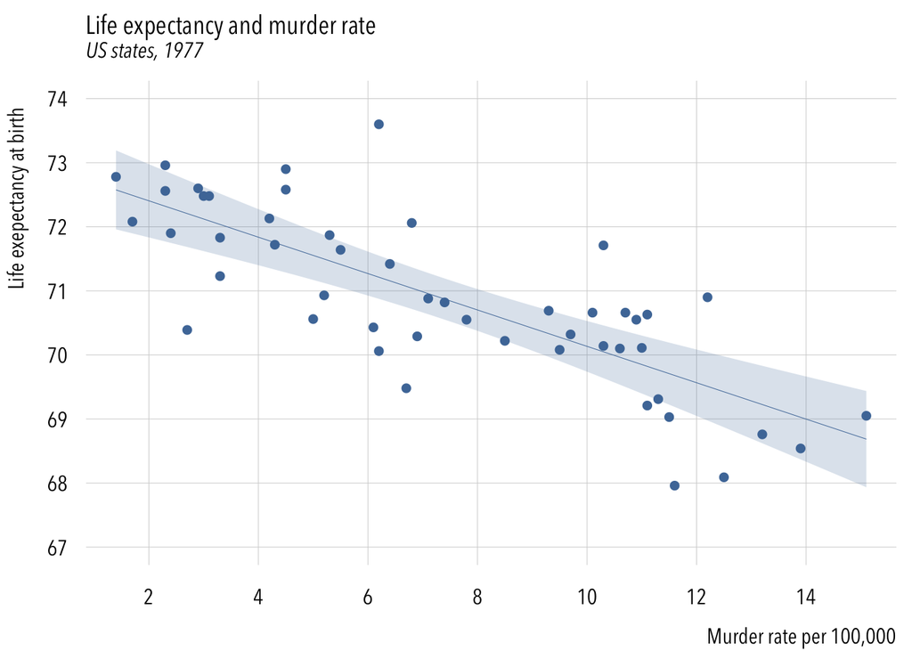

```r
plt(life_exp ~ murder,
    data = states,
    ylim = c(67, 74),
    main = "Life expectancy and murder rate",
    sub = "US states, 1977",
    xlab = "Murder rate per 100,000",
    ylab = "Life exepectancy at birth")
plt_add(type = "lm",
        level = .99)
```

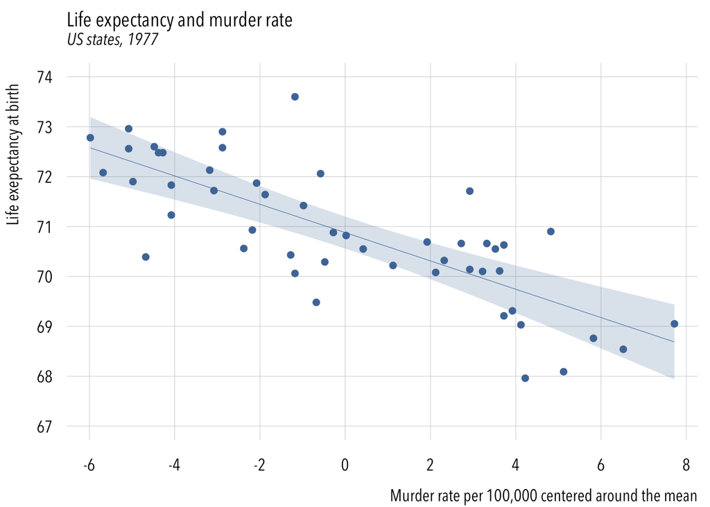

```r
plt(life_exp ~ murder_c,
    data = states,
    ylim = c(67, 74),
    main = "Life expectancy and murder rate",
    sub = "US states, 1977",
    xlab = "Murder rate per 100,000 centered around the mean",
    ylab = "Life exepectancy at birth")
plt_add(type = "lm",
        level = .99)
```

Create a transformed predictor by standardizing `murder`.

## 2c(i). Create `murder_std` and refit the model

```r
states <- states |>
  mutate(murder_std = (murder - mean(murder)) / sd(murder))

fit_stdx <- lm(life_exp ~ murder_std, data = states)

msummary(list("X std." = fit_stdx),
         fmt = 3,
         estimate = "{estimate} ({std.error})",
         statistic = NULL,
         gof_map = c("nobs", "F", "r.squared"))
```

|  | X std. |
| --- | --- |
| (Intercept) | 70.879 (0.120) |
| murder_std | -1.048 (0.121) |
| Num.Obs. | 50 |
| F | 74.989 |
| R2 | 0.610 |

## 2c(ii). Report SSE(A), SSE(C), PRE, and F again

Compute SSE, PRE, and F again and compare them to 2a and 2b.

```r
sse_std <- deviance(fit_stdx)
sse_std
```

```
[1] 34.46133
```

```r
pre_std <- (sse_c - sse_std) / sse_c
pre_std
```

```
[1] 0.6097201
```

```r
f_std <- ((sse_c - sse_std)/(pa - pc)) / (sse_std/(n - pa))
f_std
```

```
[1] 74.98865
```

The fit statistics remain the same as in 2a and 2b.

## 2c(iii). Interpret coefficients after rescaling

Write the prediction equation and interpret the slope carefully in the new units.

$$\widehat{life\_exp} = 70.87 - 1.048\, murder_{scaled}$$

For every one standard deviation unit increase in murder rate, life expectancy decreases by 1.048 years.

# Question 3: Predicted values and what transformations do (and do not) change

You now have three versions of the same basic relationship:

1. using `murder`
2. using `murder_c`
3. using `murder_std`

```r
msummary(list("Original" = model_a,
              "Centered" = fit_cent,
              "X-std." = fit_stdx),
         fmt = 3,
         estimate = "{estimate}",
         statistic = NULL,
         gof_map = c("nobs", "F", "r.squared"))
```

|  | Original | Centered | X-std. |
| --- | --- | --- | --- |
| (Intercept) | 72.974 | 70.879 | 70.879 |
| murder | -0.284 |  |  |
| murder_c |  | -0.284 |  |
| murder_std |  |  | -1.048 |
| Num.Obs. | 50 | 50 | 50 |
| F | 74.989 | 74.989 | 74.989 |
| R2 | 0.610 | 0.610 | 0.610 |

## 3a. Predicted life expectancy at a specific murder rate

Using each of your three fitted Model A versions, compute the predicted life expectancy for a state with `murder` = 8.

Show your work. (Be explicit about how you convert 8 into the appropriate value for `murder_c` and `murder_std`.)

```r
# Model A
life_exp_a <- 72.974 - .284*8
life_exp_a
```

```
[1] 70.702
```

```r
# Centered
life_exp_cent <- 70.879 - .284*.62
life_exp_cent
```

```
[1] 70.70292
```

```r
# X-standardized
z <- (8 - 7.38) / 3.69
life_exp_std <- 70.879 - 1.048*z
life_exp_std
```

```
[1] 70.70291
```

## 3b. Summary paragraph

Write a brief summary explaining what you learned about transforming a predictor:

- How do these transformations affect the estimated intercept and slope?
- Do they change predicted values (when transformed consistently)?
- Do they change overall goodness of fit (SSE, PRE, $F$)?

Centering the predictor transforms the estimated intercept so that it represents the expected outcome when the predictor is at its mean. However, it does not change the units, so the slope remains the same as in the original equation. When Standardizing the predictor, the intercept represents the expected outcome when the predictor is at its mean, but the slope is transformed so that it represents the change in the outcome for every one standard deviation unit change in the predictor. These transformations do not change the predicted values or overall goodness of fit.

# Project application

Do the same thing with an outcome and predictor of your choice from your own dataset. Use three transformations:

- original
- normalized X
- fully standardized

```r
gss2024 <- readRDS(file = here::here("data", "gss2024.rds"))

gss <- gss2024 |>
  select(courtsnv, polviews) |>
  drop_na() |>
  haven::zap_labels()

gss_recoded <- gss |>
  mutate(
    courtsdv = recode(courtsnv,
                        `1` = -1,
                        `2` = 1,
                        `3` = 0),
    polviewsdv = polviews - 4
    )

gss_recoded |>
  summarize(
    n = n(),
    mean_courts = mean(courtsdv, na.rm = TRUE),
    sd_courts = sd(courtsdv, na.rm = TRUE),
    mean_polviews = mean(polviewsdv, na.rm = TRUE),
    sd_polviews = sd(polviewsdv, na.rm = TRUE)
  )
```

```
# A tibble: 1 × 5
      n mean_courts sd_courts mean_polviews sd_polviews
  <int>       <dbl>     <dbl>         <dbl>       <dbl>
1   606       0.545     0.839       -0.0149        1.49
```

```r
m_c <- lm(courtsdv ~ 1,
          data = gss_recoded)
ssec <- deviance(m_c)

m_a <- lm(courtsdv ~ 1 + polviewsdv,
          data = gss_recoded)
ssea <- deviance(m_a)
ssea
```

```
[1] 408.6852
```

```r
pre_orig <- (ssec - ssea) / ssec
pre_orig
```

```
[1] 0.04131344
```

```r
# Centered

gss_recoded <- gss_recoded |>
  mutate(polviews_cent = polviewsdv - mean(polviewsdv))

m_cent <- lm(courtsdv ~ 1 + polviews_cent,
             data = gss_recoded)

sse_cent <- deviance(m_cent)
sse_cent
```

```
[1] 408.6852
```

```r
cent_pre <- (ssec - sse_cent) / ssec
cent_pre
```

```
[1] 0.04131344
```

```r
# X-Standardized

gss_recoded <- gss_recoded |>
  mutate(polviews_std = (polviewsdv - mean(polviewsdv)) / sd(polviewsdv))

m_stdx <- lm(courtsdv ~ 1 + polviews_std,
               data = gss_recoded)

sse_stdx <- deviance(m_stdx)

pre_stdx <- (ssec - sse_stdx) / ssec
pre_stdx
```

```
[1] 0.04131344
```

```r
# Summary

msummary(list("Original" = m_a,
              "Centered" = m_cent,
              "X-std." = m_stdx),
         fmt = 3,
         estimate = "{estimate}",
         statistic = NULL,
         gof_map = c("nobs", "F", "r.squared"))
```

|  | Original | Centered | X-std. |
| --- | --- | --- | --- |
| (Intercept) | 0.546 | 0.545 | 0.545 |
| polviewsdv | 0.114 |  |  |
| polviews_cent |  | 0.114 |  |
| polviews_std |  |  | 0.171 |
| Num.Obs. | 606 | 606 | 606 |
| F | 26.029 | 26.029 | 26.029 |
| R2 | 0.041 | 0.041 | 0.041 |

Interpret the intercepts and slopes for each of the three models. Compare the fit statistics for each of the three models.

The original model has an intercept of .546, which represents one’s opinion on the courts when one self-identifies as having moderate political views. For both the centered and X-standardized models, the intercept is .545, which represents the expected opinion on courts when one’s political views align with the mean. For the original and centered models, the slope is .114, which means that for every one point more conservative someone is, their predicted opinion score is .114 greater, meaning that they are more likely to think courts do not deal with criminals harshly enough. The slope for the X-standardized model is .171, which means that for every standard deviation unit increase in political views (i.e., being more conservative), there is an expected .171 increase in one’s opinion score, meaning that they are more likely to think courts do not deal with criminals harshly enough. For all three models, the fit statistics remain the same, with a PRE of .041 and an F-statistic of 26.029.